# INFLATION ANALYSIS IN THE US ECONOMY

# VARIABILITY ACCROSS SECTORS

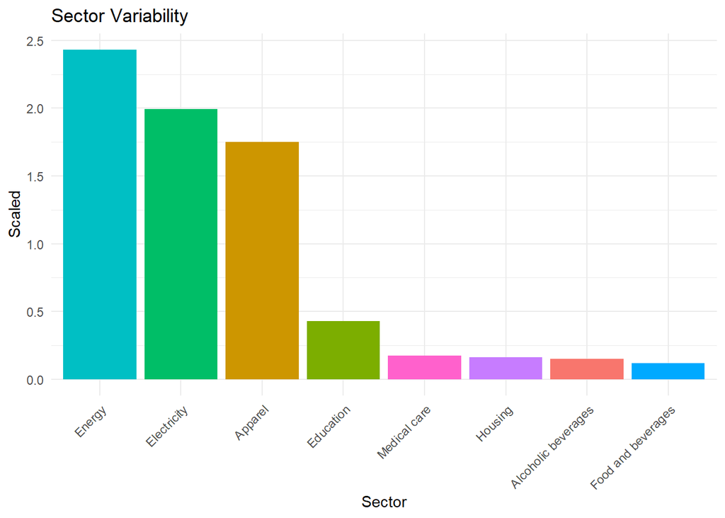

```r
data_long <- data %>%
  pivot_longer(cols = JAN:DEC, names_to = "Month", values_to = "Value")

# Calculate variability (standard deviation and coefficient of variation) for each sector
sector_variability <- data_long %>%
  group_by(TITLE) %>%
  summarize(
    Mean_CPI = mean(Value, na.rm = TRUE),
    SD_CPI = sd(Value, na.rm = TRUE),
    CV_CPI = SD_CPI / Mean_CPI * 100
  )
# the barchart shows which sectors has the highest and lowest variabilties
ggplot(sector_variability, aes(x = reorder(TITLE, -SD_CPI), y = SD_CPI, fill = TITLE)) +
  geom_bar(stat = "identity") +
  labs(title = "Sector Variability", x = "Sector", y = "Scaled") +
  theme_minimal() +
  theme(axis.text.x = element_text(angle = 45, hjust = 1), legend.position = "none")
```

After analyzing the trend patterns, CPI value distributions by year and sector, and variability across different sectors, it is evident that **energy**, **electricity**, and **apparel** exhibit significant variations and fluctuations over time. These fluctuations indicate dynamic behaviors influenced by seasonal patterns, external factors, and economic changes.

Given this variability, a **time series analysis** using ARIMA modeling was chosen to capture these patterns and predict future trends in these sectors. ARIMA is well-suited for modeling data with trends and seasonality while accommodating fluctuations in the data. Forecasting future values provides valuable insights into expected price movements, helping to understand and prepare for potential impacts in these key sectors.

# Why not the rest of the sectors?

The sectors that do not exhibit significant fluctuations, such as **housing**, **medical care**, and **education**, tend to have more stable CPI trends over time. This stability can be attributed to factors like regulated pricing, long-term contracts, and consistent demand. For example, housing prices often follow steady upward trends due to factors like inflation and gradual increases in real estate and rental costs. Similarly, medical care and education are influenced by structured pricing mechanisms and predictable consumption patterns, which reduce variability. As a result, these sectors are less prone to external shocks or seasonal effects compared to more dynamic sectors like energy and apparel.

# Time Series Analsis and Forecasting for Energy Sector

```r
# Filter data for Energy sector
energy_data <- group2_long %>%
  filter(TITLE == "Energy") %>%
  select(YEAR, Value)
```

#Converting the Energy CPI data into a time series object

```r
# Create a time series object
energy_ts <- ts(energy_data$Value, start = c(2014, 1), frequency = 12) # Monthly frequency
```

Fitting an ARIMA model to the time series data - Automatically identifies the best fitting ARIMA model by optimizing the parameters p(Autoregressive), d(Differencing), q(Moving Average) => The summary gives the p, d, q values, coefficients pf the model, Diagnostic statistics like AIC, BIC and residual standard errors

```r
# Fit ARIMA model
energy_arima <- auto.arima(energy_ts)

# Display model summary
summary(energy_arima)
```

```
## Series: energy_ts
## ARIMA(2,0,2)(1,1,0)[12]
##
## Coefficients:
##          ar1      ar2      ma1      ma2     sar1
##       0.9683  -0.1261  -0.6445  -0.3267  -0.3196
## s.e.  0.1525   0.1538   0.1449   0.1500   0.0651
##
## sigma^2 = 0.06757:  log likelihood = -14.32
## AIC=40.64   AICc=41.02   BIC=61.22
##
## Training set error measures:
##                        ME      RMSE       MAE         MPE      MAPE      MASE
## Training set -0.008592831 0.2505762 0.1713846 -0.00833891 0.1719229 0.7450792
##                     ACF1
## Training set 0.006113875
```

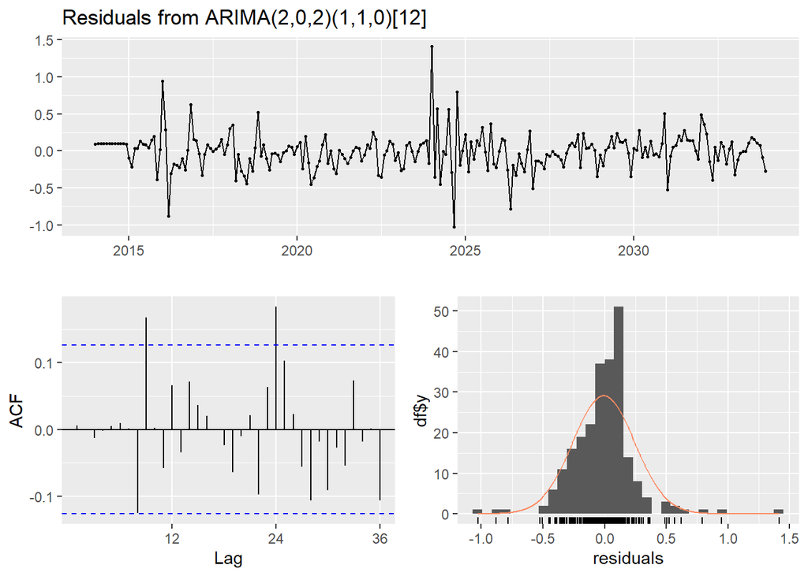

```
##
##  Ljung-Box test
##
## data:  Residuals from ARIMA(2,0,2)(1,1,0)[12]
## Q* = 29.174, df = 19, p-value = 0.0633
##
## Model df: 5.   Total lags used: 24
```

```r
# Performs diagnostic on the residuals (errors) of the fitted model - Helps validates whether the ARIMA model is appropriate for the data
checkresiduals(energy_arima)
```

# The Ljung-Box test for Energy

The results provide valuable insight into whether the residuals from the ARIMA model are independent (i.e., no significant autocorrelation remains).

The hypothesis for the Ljung-Box test is:

H₀: The residuals are independent (i.e., there is no autocorrelation in the residuals). H₁: The residuals are not independent (i.e., there is significant autocorrelation)

- Test Statistic, Q∗=29.174: This is the value of the Ljung-Box test statistic.
- Degrees of Freedom (df) = 19: This is calculated based on the number of lags minus the number of estimated parameters in the model.
- p-value = 0.0633: The p-value is slightly above the standard significance level of 0.05

Conclusion:

No Significant Autocorrelation: Since p=0.0633 is greater than 0.05, we fail to reject the null hypothesis of the Ljung-Box test. This suggests that there is no significant autocorrelation remaining in the residuals.

Model Adequacy: The residuals appear to be white noise, indicating that the ARIMA model adequately captures the patterns in the data.